# Análise descritiva do comportamento do BTC - Binance

## Importando as bibliotecas

```python
from binance.client import Client
import pandas as pd
from datetime import datetime
```

## Chaves

Nessa parte, vamos coletar informações diretamente da Binance. Para isso, vamos nos basear na documentação do link abaixo:  
https://python-binance.readthedocs.io/en/latest/overview.html

```python
api_key = ''
api_secret = ' '

client = Client(api_key, api_secret)
```

## Coletando os dados da API

```python
klines = client.get_historical_klines("BTCUSDT", Client.KLINE_INTERVAL_30MINUTE, "01 July, 2019")
```

## Tratamento dos dados

```python
Open_time = []
Open = []
High = []
Low = []
Close = []
Volume = []
Close_time = []

for k in klines:
    Open_time.append(datetime.fromtimestamp(k[0] / 1e3).strftime("%Y-%m-%d %H:%M:%S"))
    Open.append(float(k[1]))
    High.append(float(k[2]))
    Low.append(float(k[3]))
    Close.append(float(k[4]))
    Volume.append(float(k[5]))
    Close_time.append(datetime.fromtimestamp(k[6] / 1e3).strftime("%Y-%m-%d %H:%M:%S"))
```

```python
d = {'Open_time': Open_time, 'Open': Open, 'High': High, 'Low': Low, 'Close': Close, 'Volume': Volume, 'Close_time': Close_time}
df = pd.DataFrame(data = d)
df
```

|  | Open_time | Open | High | Low | Close | Volume | Close_time |
| --- | --- | --- | --- | --- | --- | --- | --- |
| 0 | 2019-06-30 21:00:00 | 10854.10 | 11047.01 | 10719.00 | 11000.15 | 3809.101509 | 2019-06-30 21:29:59 |
| 1 | 2019-06-30 21:30:00 | 11007.65 | 11104.41 | 10906.51 | 11091.54 | 1634.514334 | 2019-06-30 21:59:59 |
| 2 | 2019-06-30 22:00:00 | 11091.06 | 11171.42 | 10981.01 | 11043.70 | 2261.770915 | 2019-06-30 22:29:59 |
| 3 | 2019-06-30 22:30:00 | 11043.72 | 11110.00 | 10958.31 | 10973.34 | 1834.093975 | 2019-06-30 22:59:59 |
| 4 | 2019-06-30 23:00:00 | 10981.15 | 11090.00 | 10868.00 | 11081.18 | 2550.054610 | 2019-06-30 23:29:59 |
| 5 | 2019-06-30 23:30:00 | 11081.18 | 11148.98 | 11050.00 | 11054.94 | 1767.860627 | 2019-06-30 23:59:59 |
| 6 | 2019-07-01 00:00:00 | 11056.02 | 11197.00 | 11001.00 | 11127.85 | 1751.560374 | 2019-07-01 00:29:59 |
| 7 | 2019-07-01 00:30:00 | 11129.33 | 11282.28 | 11103.31 | 11142.98 | 2221.289998 | 2019-07-01 00:59:59 |
| 8 | 2019-07-01 01:00:00 | 11139.37 | 11178.22 | 11080.00 | 11107.19 | 1037.765091 | 2019-07-01 01:29:59 |
| 9 | 2019-07-01 01:30:00 | 11105.58 | 11224.35 | 11092.73 | 11145.92 | 872.323222 | 2019-07-01 01:59:59 |
| 10 | 2019-07-01 02:00:00 | 11144.61 | 11183.09 | 11000.00 | 11163.35 | 1850.273533 | 2019-07-01 02:29:59 |
| 11 | 2019-07-01 02:30:00 | 11163.35 | 11203.90 | 11050.00 | 11080.09 | 1021.516826 | 2019-07-01 02:59:59 |
| 12 | 2019-07-01 03:00:00 | 11078.79 | 11138.83 | 11046.25 | 11061.92 | 950.762072 | 2019-07-01 03:29:59 |
| 13 | 2019-07-01 03:30:00 | 11063.89 | 11085.68 | 10935.41 | 10962.89 | 2024.029052 | 2019-07-01 03:59:59 |
| 14 | 2019-07-01 04:00:00 | 10960.40 | 11078.63 | 10900.00 | 10945.52 | 1469.291459 | 2019-07-01 04:29:59 |
| 15 | 2019-07-01 04:30:00 | 10945.96 | 11003.83 | 10900.00 | 10983.70 | 1270.830924 | 2019-07-01 04:59:59 |
| 16 | 2019-07-01 05:00:00 | 10983.70 | 11061.53 | 10950.00 | 10997.80 | 964.261955 | 2019-07-01 05:29:59 |
| 17 | 2019-07-01 05:30:00 | 10998.00 | 11180.85 | 10998.00 | 11178.08 | 1748.515836 | 2019-07-01 05:59:59 |
| 18 | 2019-07-01 06:00:00 | 11178.13 | 11178.13 | 11076.74 | 11091.00 | 1225.407003 | 2019-07-01 06:29:59 |
| 19 | 2019-07-01 06:30:00 | 11090.63 | 11189.99 | 11072.62 | 11106.79 | 960.418143 | 2019-07-01 06:59:59 |
| 20 | 2019-07-01 07:00:00 | 11107.17 | 11146.96 | 10985.57 | 11005.12 | 1150.612583 | 2019-07-01 07:29:59 |
| 21 | 2019-07-01 07:30:00 | 11004.67 | 11030.30 | 10902.59 | 10994.45 | 1409.368502 | 2019-07-01 07:59:59 |
| 22 | 2019-07-01 08:00:00 | 10994.45 | 11037.16 | 10931.81 | 10960.63 | 959.865512 | 2019-07-01 08:29:59 |
| 23 | 2019-07-01 08:30:00 | 10964.00 | 11045.00 | 10924.00 | 11022.65 | 1044.520445 | 2019-07-01 08:59:59 |
| 24 | 2019-07-01 09:00:00 | 11020.87 | 11041.42 | 10633.33 | 10750.00 | 2818.353716 | 2019-07-01 09:29:59 |
| 25 | 2019-07-01 09:30:00 | 10748.30 | 10766.76 | 10535.00 | 10666.14 | 3953.990745 | 2019-07-01 09:59:59 |
| 26 | 2019-07-01 10:00:00 | 10665.04 | 10748.34 | 10600.10 | 10708.71 | 1795.386308 | 2019-07-01 10:29:59 |
| 27 | 2019-07-01 10:30:00 | 10708.90 | 10725.00 | 10578.08 | 10578.28 | 1602.307584 | 2019-07-01 10:59:59 |
| 28 | 2019-07-01 11:00:00 | 10578.21 | 10669.67 | 10515.00 | 10606.89 | 1909.939827 | 2019-07-01 11:29:59 |
| 29 | 2019-07-01 11:30:00 | 10606.07 | 10644.00 | 10256.01 | 10305.94 | 5322.536252 | 2019-07-01 11:59:59 |
| ... | ... | ... | ... | ... | ... | ... | ... |
| 1371 | 2019-07-29 10:30:00 | 9550.00 | 9635.96 | 9550.00 | 9569.65 | 930.789459 | 2019-07-29 10:59:59 |
| 1372 | 2019-07-29 11:00:00 | 9572.49 | 9605.99 | 9540.00 | 9554.68 | 625.105351 | 2019-07-29 11:29:59 |
| 1373 | 2019-07-29 11:30:00 | 9554.84 | 9575.00 | 9525.55 | 9556.10 | 517.055730 | 2019-07-29 11:59:59 |
| 1374 | 2019-07-29 12:00:00 | 9556.04 | 9592.00 | 9535.00 | 9572.01 | 417.317350 | 2019-07-29 12:29:59 |
| 1375 | 2019-07-29 12:30:00 | 9573.59 | 9600.00 | 9502.08 | 9539.64 | 719.401819 | 2019-07-29 12:59:59 |
| 1376 | 2019-07-29 13:00:00 | 9538.24 | 9693.98 | 9411.31 | 9587.21 | 2458.344971 | 2019-07-29 13:29:59 |
| 1377 | 2019-07-29 13:30:00 | 9584.75 | 9599.00 | 9530.00 | 9552.05 | 702.466995 | 2019-07-29 13:59:59 |
| 1378 | 2019-07-29 14:00:00 | 9548.45 | 9566.61 | 9525.80 | 9548.14 | 421.966092 | 2019-07-29 14:29:59 |
| 1379 | 2019-07-29 14:30:00 | 9550.00 | 9561.81 | 9425.02 | 9499.52 | 1260.956721 | 2019-07-29 14:59:59 |
| 1380 | 2019-07-29 15:00:00 | 9502.79 | 9505.98 | 9451.94 | 9488.74 | 578.692691 | 2019-07-29 15:29:59 |
| 1381 | 2019-07-29 15:30:00 | 9488.18 | 9534.55 | 9477.86 | 9519.55 | 319.765942 | 2019-07-29 15:59:59 |
| 1382 | 2019-07-29 16:00:00 | 9520.60 | 9530.67 | 9485.87 | 9518.39 | 276.386101 | 2019-07-29 16:29:59 |
| 1383 | 2019-07-29 16:30:00 | 9515.74 | 9522.40 | 9480.00 | 9487.63 | 267.485447 | 2019-07-29 16:59:59 |
| 1384 | 2019-07-29 17:00:00 | 9489.81 | 9510.00 | 9470.00 | 9503.26 | 251.781357 | 2019-07-29 17:29:59 |
| 1385 | 2019-07-29 17:30:00 | 9503.48 | 9538.11 | 9490.59 | 9526.46 | 386.613554 | 2019-07-29 17:59:59 |
| 1386 | 2019-07-29 18:00:00 | 9527.50 | 9548.92 | 9521.12 | 9542.25 | 236.652460 | 2019-07-29 18:29:59 |
| 1387 | 2019-07-29 18:30:00 | 9542.98 | 9543.41 | 9509.95 | 9511.44 | 191.956741 | 2019-07-29 18:59:59 |
| 1388 | 2019-07-29 19:00:00 | 9511.45 | 9522.02 | 9483.33 | 9512.09 | 345.123742 | 2019-07-29 19:29:59 |
| 1389 | 2019-07-29 19:30:00 | 9512.10 | 9549.00 | 9502.12 | 9532.30 | 222.895492 | 2019-07-29 19:59:59 |
| 1390 | 2019-07-29 20:00:00 | 9531.96 | 9542.99 | 9507.00 | 9535.00 | 271.615618 | 2019-07-29 20:29:59 |
| 1391 | 2019-07-29 20:30:00 | 9534.98 | 9538.97 | 9450.00 | 9507.64 | 1021.363496 | 2019-07-29 20:59:59 |
| 1392 | 2019-07-29 21:00:00 | 9509.07 | 9535.00 | 9503.07 | 9517.75 | 381.293856 | 2019-07-29 21:29:59 |
| 1393 | 2019-07-29 21:30:00 | 9517.03 | 9539.00 | 9507.00 | 9532.58 | 258.514869 | 2019-07-29 21:59:59 |
| 1394 | 2019-07-29 22:00:00 | 9533.59 | 9534.00 | 9500.00 | 9500.25 | 275.797270 | 2019-07-29 22:29:59 |
| 1395 | 2019-07-29 22:30:00 | 9500.25 | 9514.46 | 9460.71 | 9465.25 | 485.218470 | 2019-07-29 22:59:59 |
| 1396 | 2019-07-29 23:00:00 | 9465.25 | 9488.94 | 9430.01 | 9460.42 | 498.669626 | 2019-07-29 23:29:59 |
| 1397 | 2019-07-29 23:30:00 | 9461.73 | 9470.46 | 9402.00 | 9425.55 | 1877.784054 | 2019-07-29 23:59:59 |
| 1398 | 2019-07-30 00:00:00 | 9425.60 | 9453.58 | 9403.00 | 9431.45 | 598.190032 | 2019-07-30 00:29:59 |
| 1399 | 2019-07-30 00:30:00 | 9431.49 | 9449.83 | 9425.00 | 9441.29 | 297.390720 | 2019-07-30 00:59:59 |
| 1400 | 2019-07-30 01:00:00 | 9441.04 | 9460.90 | 9430.00 | 9449.23 | 193.376108 | 2019-07-30 01:29:59 |

1401 rows × 7 columns

Como podemos ver, temos dados do volume, abertura, fechamento do ativo. Com isso é possível criarmos novas features e assim termos insights do ativo ao longo do tempo.

## Criando features

```python
from datetime import datetime

def diff_days(date1, date2):
    d1 = datetime.strptime(date1, '%Y-%m-%d %H:%M:%S')
    d2 = datetime.strptime(date2, '%Y-%m-%d %H:%M:%S')
    d = abs((d2 - d1).seconds)
    d = (d % 3600) // 60
    return d
```

```python
close_open_time = []

for i in range(len(df)):
    close_open_time.append(diff_days(df.iloc[i][0] , df.iloc[i][6]))

close_open_time = pd.DataFrame(close_open_time)
close_open_time.columns = ['Dif_close_open_time_seconds']
df2 =pd.concat([df,close_open_time], axis = 1)
```

```python
close_open = []

for i in range(len(df)):
    close_open.append(df.iloc[i][4] - df.iloc[i][1])

close_open = pd.DataFrame(close_open)
close_open.columns = ['Dif_close_open']
df2 = pd.concat([df2,close_open], axis = 1)
```

```python
close_open_1 = []

for i in range(len(df2)):
    if df2.iloc[i][8] > 0:
        close_open_1.append(1)
    else:
        close_open_1.append(0)

close_open_1 = pd.DataFrame(close_open_1)
close_open_1.columns = ['Dif_close_open_flag']
data = pd.concat([df2,close_open_1], axis = 1)
```

```python
data
```

|  | Open_time | Open | High | Low | Close | Volume | Close_time | Dif_close_open_time_seconds | Dif_close_open | Dif_close_open_flag |
| --- | --- | --- | --- | --- | --- | --- | --- | --- | --- | --- |
| 0 | 2019-06-30 21:00:00 | 10854.10 | 11047.01 | 10719.00 | 11000.15 | 3809.101509 | 2019-06-30 21:29:59 | 29 | 146.05 | 1 |
| 1 | 2019-06-30 21:30:00 | 11007.65 | 11104.41 | 10906.51 | 11091.54 | 1634.514334 | 2019-06-30 21:59:59 | 29 | 83.89 | 1 |
| 2 | 2019-06-30 22:00:00 | 11091.06 | 11171.42 | 10981.01 | 11043.70 | 2261.770915 | 2019-06-30 22:29:59 | 29 | -47.36 | 0 |
| 3 | 2019-06-30 22:30:00 | 11043.72 | 11110.00 | 10958.31 | 10973.34 | 1834.093975 | 2019-06-30 22:59:59 | 29 | -70.38 | 0 |
| 4 | 2019-06-30 23:00:00 | 10981.15 | 11090.00 | 10868.00 | 11081.18 | 2550.054610 | 2019-06-30 23:29:59 | 29 | 100.03 | 1 |
| 5 | 2019-06-30 23:30:00 | 11081.18 | 11148.98 | 11050.00 | 11054.94 | 1767.860627 | 2019-06-30 23:59:59 | 29 | -26.24 | 0 |
| 6 | 2019-07-01 00:00:00 | 11056.02 | 11197.00 | 11001.00 | 11127.85 | 1751.560374 | 2019-07-01 00:29:59 | 29 | 71.83 | 1 |
| 7 | 2019-07-01 00:30:00 | 11129.33 | 11282.28 | 11103.31 | 11142.98 | 2221.289998 | 2019-07-01 00:59:59 | 29 | 13.65 | 1 |
| 8 | 2019-07-01 01:00:00 | 11139.37 | 11178.22 | 11080.00 | 11107.19 | 1037.765091 | 2019-07-01 01:29:59 | 29 | -32.18 | 0 |
| 9 | 2019-07-01 01:30:00 | 11105.58 | 11224.35 | 11092.73 | 11145.92 | 872.323222 | 2019-07-01 01:59:59 | 29 | 40.34 | 1 |
| 10 | 2019-07-01 02:00:00 | 11144.61 | 11183.09 | 11000.00 | 11163.35 | 1850.273533 | 2019-07-01 02:29:59 | 29 | 18.74 | 1 |
| 11 | 2019-07-01 02:30:00 | 11163.35 | 11203.90 | 11050.00 | 11080.09 | 1021.516826 | 2019-07-01 02:59:59 | 29 | -83.26 | 0 |
| 12 | 2019-07-01 03:00:00 | 11078.79 | 11138.83 | 11046.25 | 11061.92 | 950.762072 | 2019-07-01 03:29:59 | 29 | -16.87 | 0 |
| 13 | 2019-07-01 03:30:00 | 11063.89 | 11085.68 | 10935.41 | 10962.89 | 2024.029052 | 2019-07-01 03:59:59 | 29 | -101.00 | 0 |
| 14 | 2019-07-01 04:00:00 | 10960.40 | 11078.63 | 10900.00 | 10945.52 | 1469.291459 | 2019-07-01 04:29:59 | 29 | -14.88 | 0 |
| 15 | 2019-07-01 04:30:00 | 10945.96 | 11003.83 | 10900.00 | 10983.70 | 1270.830924 | 2019-07-01 04:59:59 | 29 | 37.74 | 1 |
| 16 | 2019-07-01 05:00:00 | 10983.70 | 11061.53 | 10950.00 | 10997.80 | 964.261955 | 2019-07-01 05:29:59 | 29 | 14.10 | 1 |
| 17 | 2019-07-01 05:30:00 | 10998.00 | 11180.85 | 10998.00 | 11178.08 | 1748.515836 | 2019-07-01 05:59:59 | 29 | 180.08 | 1 |
| 18 | 2019-07-01 06:00:00 | 11178.13 | 11178.13 | 11076.74 | 11091.00 | 1225.407003 | 2019-07-01 06:29:59 | 29 | -87.13 | 0 |
| 19 | 2019-07-01 06:30:00 | 11090.63 | 11189.99 | 11072.62 | 11106.79 | 960.418143 | 2019-07-01 06:59:59 | 29 | 16.16 | 1 |
| 20 | 2019-07-01 07:00:00 | 11107.17 | 11146.96 | 10985.57 | 11005.12 | 1150.612583 | 2019-07-01 07:29:59 | 29 | -102.05 | 0 |
| 21 | 2019-07-01 07:30:00 | 11004.67 | 11030.30 | 10902.59 | 10994.45 | 1409.368502 | 2019-07-01 07:59:59 | 29 | -10.22 | 0 |
| 22 | 2019-07-01 08:00:00 | 10994.45 | 11037.16 | 10931.81 | 10960.63 | 959.865512 | 2019-07-01 08:29:59 | 29 | -33.82 | 0 |
| 23 | 2019-07-01 08:30:00 | 10964.00 | 11045.00 | 10924.00 | 11022.65 | 1044.520445 | 2019-07-01 08:59:59 | 29 | 58.65 | 1 |
| 24 | 2019-07-01 09:00:00 | 11020.87 | 11041.42 | 10633.33 | 10750.00 | 2818.353716 | 2019-07-01 09:29:59 | 29 | -270.87 | 0 |
| 25 | 2019-07-01 09:30:00 | 10748.30 | 10766.76 | 10535.00 | 10666.14 | 3953.990745 | 2019-07-01 09:59:59 | 29 | -82.16 | 0 |
| 26 | 2019-07-01 10:00:00 | 10665.04 | 10748.34 | 10600.10 | 10708.71 | 1795.386308 | 2019-07-01 10:29:59 | 29 | 43.67 | 1 |
| 27 | 2019-07-01 10:30:00 | 10708.90 | 10725.00 | 10578.08 | 10578.28 | 1602.307584 | 2019-07-01 10:59:59 | 29 | -130.62 | 0 |
| 28 | 2019-07-01 11:00:00 | 10578.21 | 10669.67 | 10515.00 | 10606.89 | 1909.939827 | 2019-07-01 11:29:59 | 29 | 28.68 | 1 |
| 29 | 2019-07-01 11:30:00 | 10606.07 | 10644.00 | 10256.01 | 10305.94 | 5322.536252 | 2019-07-01 11:59:59 | 29 | -300.13 | 0 |
| ... | ... | ... | ... | ... | ... | ... | ... | ... | ... | ... |
| 1371 | 2019-07-29 10:30:00 | 9550.00 | 9635.96 | 9550.00 | 9569.65 | 930.789459 | 2019-07-29 10:59:59 | 29 | 19.65 | 1 |
| 1372 | 2019-07-29 11:00:00 | 9572.49 | 9605.99 | 9540.00 | 9554.68 | 625.105351 | 2019-07-29 11:29:59 | 29 | -17.81 | 0 |
| 1373 | 2019-07-29 11:30:00 | 9554.84 | 9575.00 | 9525.55 | 9556.10 | 517.055730 | 2019-07-29 11:59:59 | 29 | 1.26 | 1 |
| 1374 | 2019-07-29 12:00:00 | 9556.04 | 9592.00 | 9535.00 | 9572.01 | 417.317350 | 2019-07-29 12:29:59 | 29 | 15.97 | 1 |
| 1375 | 2019-07-29 12:30:00 | 9573.59 | 9600.00 | 9502.08 | 9539.64 | 719.401819 | 2019-07-29 12:59:59 | 29 | -33.95 | 0 |
| 1376 | 2019-07-29 13:00:00 | 9538.24 | 9693.98 | 9411.31 | 9587.21 | 2458.344971 | 2019-07-29 13:29:59 | 29 | 48.97 | 1 |
| 1377 | 2019-07-29 13:30:00 | 9584.75 | 9599.00 | 9530.00 | 9552.05 | 702.466995 | 2019-07-29 13:59:59 | 29 | -32.70 | 0 |
| 1378 | 2019-07-29 14:00:00 | 9548.45 | 9566.61 | 9525.80 | 9548.14 | 421.966092 | 2019-07-29 14:29:59 | 29 | -0.31 | 0 |
| 1379 | 2019-07-29 14:30:00 | 9550.00 | 9561.81 | 9425.02 | 9499.52 | 1260.956721 | 2019-07-29 14:59:59 | 29 | -50.48 | 0 |
| 1380 | 2019-07-29 15:00:00 | 9502.79 | 9505.98 | 9451.94 | 9488.74 | 578.692691 | 2019-07-29 15:29:59 | 29 | -14.05 | 0 |
| 1381 | 2019-07-29 15:30:00 | 9488.18 | 9534.55 | 9477.86 | 9519.55 | 319.765942 | 2019-07-29 15:59:59 | 29 | 31.37 | 1 |
| 1382 | 2019-07-29 16:00:00 | 9520.60 | 9530.67 | 9485.87 | 9518.39 | 276.386101 | 2019-07-29 16:29:59 | 29 | -2.21 | 0 |
| 1383 | 2019-07-29 16:30:00 | 9515.74 | 9522.40 | 9480.00 | 9487.63 | 267.485447 | 2019-07-29 16:59:59 | 29 | -28.11 | 0 |
| 1384 | 2019-07-29 17:00:00 | 9489.81 | 9510.00 | 9470.00 | 9503.26 | 251.781357 | 2019-07-29 17:29:59 | 29 | 13.45 | 1 |
| 1385 | 2019-07-29 17:30:00 | 9503.48 | 9538.11 | 9490.59 | 9526.46 | 386.613554 | 2019-07-29 17:59:59 | 29 | 22.98 | 1 |
| 1386 | 2019-07-29 18:00:00 | 9527.50 | 9548.92 | 9521.12 | 9542.25 | 236.652460 | 2019-07-29 18:29:59 | 29 | 14.75 | 1 |
| 1387 | 2019-07-29 18:30:00 | 9542.98 | 9543.41 | 9509.95 | 9511.44 | 191.956741 | 2019-07-29 18:59:59 | 29 | -31.54 | 0 |
| 1388 | 2019-07-29 19:00:00 | 9511.45 | 9522.02 | 9483.33 | 9512.09 | 345.123742 | 2019-07-29 19:29:59 | 29 | 0.64 | 1 |
| 1389 | 2019-07-29 19:30:00 | 9512.10 | 9549.00 | 9502.12 | 9532.30 | 222.895492 | 2019-07-29 19:59:59 | 29 | 20.20 | 1 |
| 1390 | 2019-07-29 20:00:00 | 9531.96 | 9542.99 | 9507.00 | 9535.00 | 271.615618 | 2019-07-29 20:29:59 | 29 | 3.04 | 1 |
| 1391 | 2019-07-29 20:30:00 | 9534.98 | 9538.97 | 9450.00 | 9507.64 | 1021.363496 | 2019-07-29 20:59:59 | 29 | -27.34 | 0 |
| 1392 | 2019-07-29 21:00:00 | 9509.07 | 9535.00 | 9503.07 | 9517.75 | 381.293856 | 2019-07-29 21:29:59 | 29 | 8.68 | 1 |
| 1393 | 2019-07-29 21:30:00 | 9517.03 | 9539.00 | 9507.00 | 9532.58 | 258.514869 | 2019-07-29 21:59:59 | 29 | 15.55 | 1 |
| 1394 | 2019-07-29 22:00:00 | 9533.59 | 9534.00 | 9500.00 | 9500.25 | 275.797270 | 2019-07-29 22:29:59 | 29 | -33.34 | 0 |
| 1395 | 2019-07-29 22:30:00 | 9500.25 | 9514.46 | 9460.71 | 9465.25 | 485.218470 | 2019-07-29 22:59:59 | 29 | -35.00 | 0 |
| 1396 | 2019-07-29 23:00:00 | 9465.25 | 9488.94 | 9430.01 | 9460.42 | 498.669626 | 2019-07-29 23:29:59 | 29 | -4.83 | 0 |
| 1397 | 2019-07-29 23:30:00 | 9461.73 | 9470.46 | 9402.00 | 9425.55 | 1877.784054 | 2019-07-29 23:59:59 | 29 | -36.18 | 0 |
| 1398 | 2019-07-30 00:00:00 | 9425.60 | 9453.58 | 9403.00 | 9431.45 | 598.190032 | 2019-07-30 00:29:59 | 29 | 5.85 | 1 |
| 1399 | 2019-07-30 00:30:00 | 9431.49 | 9449.83 | 9425.00 | 9441.29 | 297.390720 | 2019-07-30 00:59:59 | 29 | 9.80 | 1 |
| 1400 | 2019-07-30 01:00:00 | 9441.04 | 9460.90 | 9430.00 | 9449.23 | 193.376108 | 2019-07-30 01:29:59 | 29 | 8.19 | 1 |

1401 rows × 10 columns

## Analise Descritiva

Agora vamos iniciar uma serie de análises descritivas dos dados afim de encontrar padrões.

```python
data.describe()
```

|  | Open | High | Low | Close | Volume | Dif_close_open_time_seconds | Dif_close_open | Dif_close_open_flag |
| --- | --- | --- | --- | --- | --- | --- | --- | --- |
| count | 1401.000000 | 1401.000000 | 1401.000000 | 1401.000000 | 1401.000000 | 1401.0 | 1401.000000 | 1401.000000 |
| mean | 10713.901306 | 10770.785275 | 10651.936524 | 10712.907473 | 1298.351590 | 29.0 | -0.993833 | 0.490364 |
| std | 884.993306 | 890.822704 | 878.000648 | 885.687896 | 1122.038765 | 0.0 | 85.277706 | 0.500086 |
| min | 9157.040000 | 9245.000000 | 9060.000000 | 9157.020000 | 150.354022 | 29.0 | -532.350000 | 0.000000 |
| 25% | 9965.480000 | 10012.490000 | 9900.000000 | 9963.740000 | 598.190032 | 29.0 | -33.700000 | 0.000000 |
| 50% | 10591.770000 | 10642.850000 | 10544.080000 | 10591.210000 | 964.188840 | 29.0 | -0.900000 | 0.000000 |
| 75% | 11361.150000 | 11415.540000 | 11300.000000 | 11361.270000 | 1593.147456 | 29.0 | 33.570000 | 1.000000 |
| max | 13055.990000 | 13147.080000 | 13010.000000 | 13055.410000 | 10484.712118 | 29.0 | 838.170000 | 1.000000 |

De acordo com a descrição acima, a média da diferença do valor de fechamento e abertura é negativa, ou seja, possivelmente houve queda no valor do Bitcoin durante o período observado. Um outro indício desse fator é que para 50% dos dados observados a diferença de fechamento e abertura do ativo também é negativa.  
Agora vamos observar alguns gráficos que podem nos trazer novos insights.

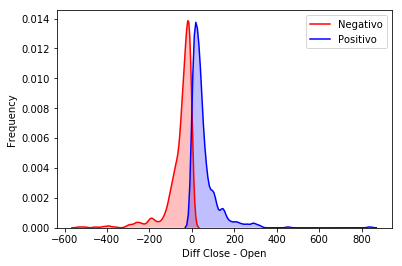

```python
import seaborn as sns
import sklearn as sk
import matplotlib.pyplot as plt
%matplotlib inline
import numpy as np

g = sns.kdeplot(data["Dif_close_open"][(data["Dif_close_open_flag"] == 0) & (data["Dif_close_open"].notnull())], color="Red", shade = True)
g = sns.kdeplot(data["Dif_close_open"][(data["Dif_close_open_flag"] == 1) & (data["Dif_close_open"].notnull())], ax =g, color="Blue", shade= True)
g.set_xlabel("Diff Close - Open")
g.set_ylabel("Frequency")
g = g.legend(["Negativo","Positivo"])
```

Percebemos que no gráfico acima, temos uma simetria dos dados para diferença de fechamento e abertura do valor do BTC ao longo do tempo. Com isso conseguimos perceber que embora exista uma volatividade do valor do ativo no periodo analisado, há um equilibrio de altas e baixas desses valores.

### Correlação de Features e classe

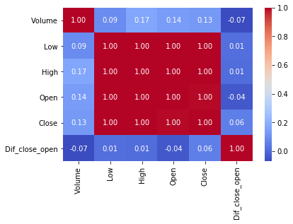

```python
g = sns.heatmap(data[["Volume","Low","High", "Open", "Close", "Dif_close_open"]].corr(),annot=True, fmt = ".2f", cmap = "coolwarm")
```

No gráfico correlações acima é notável que há uma correlação muito alta entre valores de abertura, fechamento, alta e baixa, contudo quando comparadas as outras classes e features, a correlação não é muito significativa.  
Isso fica muito claro quando observamos os seguintes gráficos:

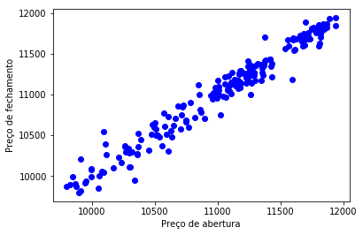

```python
x = dataset.Open[:200]
y = dataset.Close[:200]
plt.scatter(x,y,color='b')
plt.xlabel('Preço de abertura')
plt.ylabel('Preço de fechamento')
plt.axis([min(x),max(x),min(y),max(y)])
plt.autoscale('False')
plt.show()
```

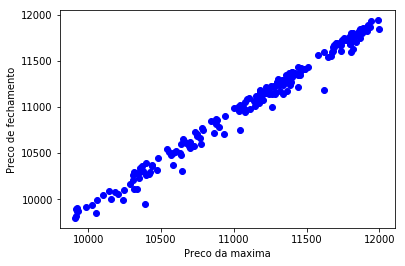

```python
x = dataset.High[:200]
y = dataset.Close[:200]
plt.scatter(x,y,color='b')
plt.xlabel('Preco da maxima')
plt.ylabel('Preco de fechamento')
plt.axis([min(x),max(x),min(y),max(y)])
plt.autoscale('False')
plt.show()
```

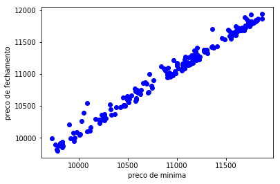

```python
x = dataset.Low[:200]
y = dataset.Close[:200]
plt.scatter(x,y,color='b')
plt.xlabel('preco de minima')
plt.ylabel('preco de fechamento')
plt.axis([min(x),max(x),min(y),max(y)])
plt.autoscale('False')
plt.show()
```

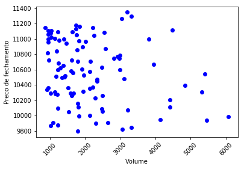

```python
x = dataset.Volume[:100]
y = dataset.Close[:100]
plt.scatter(x,y,color='b')
plt.xlabel('Volume')
plt.ylabel('Preco de fechamento')
plt.axis([min(x),max(x),min(y),max(y)])
plt.ticklabel_format(style='plain', axis='x')
plt.autoscale('False')
plt.xticks(rotation=45)
plt.show()
```

Nesse último gráfico temos a dispersão volume comparado ao preço do fechamento. É possível identificar que há uma concentração dos dados em volumes menores, no entanto, há uma volatividade dos dados no valor de fechamento, isso explica uma correlação não muito significativa.

### Variação dos Preços

Na analise a seguir temos a volatividade do preço durante do período observado.

[figure not shown]

```python
import matplotlib.dates as mdates
import datetime as dt

x = dataset['Close_time']
y = dataset['Dif_close_open']

plt.plot_date(x,y, color='r',fmt="r-")
plt.xticks(rotation=30)

plt.show()
```

É possível identificar que a frequência relativa dos valores negativos da diferença de abertura e fechamento do valor Bitcoin é superior a frequência positiva. Isso já era esperado, como visto a média dessa diferença de preços foi negativa.

Vimos que as análises acima foram de suma importância para entender o comportamento do ativo no intervalo de tempo analisado. Contudo, essas análises ainda não são suficientes para tomarmos decisões em nossos investimentos.

Como podemos através dessas informações termos insumos na hora do investimento?

## Introdução a Análise Técnica

```python
import plotly.offline as py

import plotly.graph_objs as go

import plotly
plotly.__version__

plotly.offline.init_notebook_mode()
```

```python
dataset = data
dataset.head()
```

|  | Open_time | Open | High | Low | Close | Volume | Close_time | Dif_close_open_time_seconds | Dif_close_open | Dif_close_open_flag |
| --- | --- | --- | --- | --- | --- | --- | --- | --- | --- | --- |
| 0 | 2019-06-30 21:00:00 | 10854.10 | 11047.01 | 10719.00 | 11000.15 | 3809.101509 | 2019-06-30 21:29:59 | 29 | 146.05 | 1 |
| 1 | 2019-06-30 21:30:00 | 11007.65 | 11104.41 | 10906.51 | 11091.54 | 1634.514334 | 2019-06-30 21:59:59 | 29 | 83.89 | 1 |
| 2 | 2019-06-30 22:00:00 | 11091.06 | 11171.42 | 10981.01 | 11043.70 | 2261.770915 | 2019-06-30 22:29:59 | 29 | -47.36 | 0 |
| 3 | 2019-06-30 22:30:00 | 11043.72 | 11110.00 | 10958.31 | 10973.34 | 1834.093975 | 2019-06-30 22:59:59 | 29 | -70.38 | 0 |
| 4 | 2019-06-30 23:00:00 | 10981.15 | 11090.00 | 10868.00 | 11081.18 | 2550.054610 | 2019-06-30 23:29:59 | 29 | 100.03 | 1 |

Estamos usando o mesmo dataset anterior, agora estamos interessados em analisar o valor da ação durante todo o período, abaixo temos uma gráfico que nos diz exatamente o valor do fechamento do ativo em função da data e hora.

```python
x1=dataset.Close_time
y1=dataset.Close
data = [go.Scatter(x=x1, y=y1)]
layout = go.Layout(
   xaxis=dict(
       range=['2019-07-01 21:00:00','2019-07-28 17:29:59'],
       title='Dia'
   ),
   yaxis=dict(
       range=[min(x1), max(y1)],
       title='Valor da Ação'
   ))
fig = go.Figure(data = data, layout = layout)
py.iplot(fig)
```

[interactive chart not shown]

Uma outra maneira de observar esses dados, porém com mais informações, é utilizando Candlestick. É um método de representação de gráficos amplamente utilizado no mercado de ações. Cada candle é formado por quatro pontos relativos à um determinado período (dia, hora, minuto, mês, etc) que se está analisando: o preço de abertura, de fechamento, a máxima e a mínima.

### Candlesticks

```python
# candles
dataset2 = dataset
dados = go.Candlestick(x=dataset2.Close_time,
                       open=dataset2.Open,
                       high=dataset2.High,
                       low=dataset2.Low,
                       close=dataset2.Close,
                       )
data=[dados]
py.offline.iplot(data,filename='grafico_candlestick')
```

[interactive chart not shown]

### High and Low

[figure not shown]

```python
dataset2[['High', 'Low']].plot(figsize=(15, 4), title='Hith&Low', grid=True)
```

Agora, como criar um primeiro indicadores do preço do ativo para possívelmente sabermos a hora certa de comprar ou vender? Vamos apresentar um dos indicadores mais conhecidos entre os analistas e traders do mercado financeiro:

### Médias Móveis

Serve para identificar a tendência do volume transacionado, quebras de tendências nos preços e rompimentos de suportes e resistências.

```python
# Média movel de 2 dias do Fechamento
dataset2['MovingMean2'] = dataset2.Close.rolling(2).mean()
# Média movel de 3 dias do Fechamento
dataset2['MovingMean3'] = dataset2.Close.rolling(3).mean()
# Retorno diário percentual
dataset2['DailyReturn'] = dataset2.Close.pct_change()
dataset2.tail()
```

[output not shown]

[figure not shown]

```python
# Vamos plotar o valor de fechamento e suas médias móveis para compararmos.
columns = ['Close','MovingMean2', 'MovingMean3']
graph = dataset2[columns].plot(figsize=(15, 4), grid=True)
```

# Conclusão

Utilizando uma ferramenta analítica, nesse caso o Python, fomos capazes de fazer algumas análises que nos trouxeram insights sobre o comportamento de um ativo em um certo período de tempo. Essa é apenas uma de diversas técnicas que são utilizadas como indicadores para tomadas de decisões onde temos um universo limitado de dados sobre o ativo, como preço de fechamento, abertura, máxima, mínima, etc.

Obviamente uma série de fatores deve ser considerada na hora de tentar antecipar o preço de um ativo, mas analisar o seu perfil passado já nos traz uma noção da dimensão dos seus retornos, da sua volatilidade e outros detalhes que passam despercebidos quando olhamos apenas as cotações.